# Fixed Effects vs Random Effects: A Terminology Guide

Reconciling Econometrics and Biostatistics Language

## 1. The Terminology Problem

**WarningTerminology Alert**

**“Random effects” and “fixed effects” mean completely different things in biostatistics vs econometrics!** This is one of the most confusing terminology conflicts in statistics. When reading papers or textbooks, always check which framework the authors are using.

If you are coming from a biostatistics background and encounter econometrics literature (or vice versa), you may find yourself completely confused. The same terms refer to different concepts, different estimators, and different assumptions.

This handout provides a translation guide between the two frameworks and explains when each approach is appropriate.

### The Core Confusion

| When someone says… | A biostatistician thinks… | An econometrician thinks… |
| --- | --- | --- |
| “Random effects model” | Mixed model with random intercepts/slopes | Swamy-Arora GLS estimator assuming no endogeneity |
| “Fixed effects model” | Model with only fixed (population-level) parameters | Within-transformation estimator that removes time-invariant confounding |
| “Fixed effects” | The $\beta$ coefficients in a mixed model | Individual-specific intercepts (nuisance parameters) |
| “Random effects” | The $b_i$ deviations from the population mean | An estimation approach, not model components |

## 2. Translation Table

This is the critical reference table for translating between frameworks.

Translation Between Frameworks

| Term | Biostatistics (nlme/lme4) | Econometrics (plm) |
| --- | --- | --- |
| Random effects | Subject-specific deviations $b_i$ from population mean | Swamy-Arora GLS estimator assuming $\text{Cor}(X_{it}, \alpha_i) = 0$ |
| Fixed effects | Population-level parameters $\beta$ (the coefficients of interest) | Within-transformation (demeaning) estimator |
| Mixed model | Model with both fixed $\beta$ and random $b_i$ components | (Not used in this way) |
| RE model | Model with random intercepts and/or slopes | Estimation assuming no endogeneity |
| FE model | (Not commonly used this way) | Within estimator that removes time-invariant confounding |
| Random intercept | Subject-specific baseline: $\beta_0 + b_{0i}$ | Individual effect $\alpha_i$ (may be correlated with covariates) |
| Between estimator | (Not commonly used) | OLS on subject means $\bar{Y}_i$ on $\bar{X}_i$ |
| Within estimator | (Not commonly used) | OLS on demeaned data: $(Y_{it} - \bar{Y}_i)$ on $(X_{it} - \bar{X}_i)$ |

### Mathematical Notation Comparison

**Biostatistics (Mixed Model) Notation:**
$$Y_{it} = \mathbf{X}_{it}^\top \boldsymbol{\beta} + \mathbf{Z}_{it}^\top \mathbf{b}_i + \epsilon_{it}$$

where:

- $\boldsymbol{\beta}$ = fixed effects (population parameters)
- $\mathbf{b}_i \sim N(\mathbf{0}, \mathbf{D})$ = random effects (subject deviations)
- $\epsilon_{it} \sim N(0, \sigma^2)$ = residual error

**Econometrics (Panel Data) Notation:**
$$Y_{it} = \mathbf{X}_{it}^\top \boldsymbol{\beta} + \alpha_i + \epsilon_{it}$$

where:

- $\boldsymbol{\beta}$ = coefficients of interest
- $\alpha_i$ = individual effect (may or may not be random)
- $\epsilon_{it}$ = idiosyncratic error

The key difference: econometrics focuses on whether $\alpha_i$ is correlated with $\mathbf{X}_{it}$.

## 3. When Each Framework Applies

When Each Framework Applies

| Situation | Biostatistics Approach | Econometrics Approach |
| --- | --- | --- |
| Randomized experiment | Mixed model works well | Either FE or RE works |
| Observational data with potential confounding | Mixed model + careful covariate adjustment | FE estimator preferred (removes confounding) |
| Interest in time-invariant predictors (e.g., sex, race) | Mixed model (can estimate these coefficients) | RE estimator only (FE eliminates these) |
| Interest in within-subject change | Mixed model or GEE | FE estimator (focuses on within variation) |
| Small number of subjects, many timepoints | Mixed model with careful variance specification | FE may have many parameters |
| Many subjects, few timepoints | Mixed model or GEE | Either approach works |
| Missing data (MAR assumption reasonable) | Mixed model (likelihood-based) | Complete cases or specific methods needed |
| Unbalanced panel data | Mixed model handles naturally | Both handle unbalanced data |

## 4. The Endogeneity Issue

The fundamental question in econometrics is: **Is there endogeneity?**

### What Is Endogeneity?

Endogeneity occurs when covariates are correlated with the individual-specific effect:

$$\text{Cor}(X_{it}, \alpha_i) \neq 0$$

This can happen due to:

1. **Omitted variable bias**: An unobserved time-invariant factor affects both $X$ and $Y$
2. **Selection**: Subjects self-select into treatment based on unobserved characteristics
3. **Reverse causality**: Past outcomes affect current covariates

### Why It Matters

**ImportantKey Insight**

If endogeneity exists, the RE estimator (econometrics sense) is **biased and inconsistent**. The biostatistics mixed model is also biased under these conditions, though this is less emphasized in that literature.

**Example**: Studying the effect of job training on wages

- $Y_{it}$ = wages for person $i$ at time $t$
- $X_{it}$ = 1 if person received job training
- $\alpha_i$ = unobserved ability

If more able workers are more likely to seek training, then $\text{Cor}(X_{it}, \alpha_i) > 0$, and a naive analysis will overestimate the training effect.

### How FE Solves the Problem

The FE (within) estimator uses demeaning to remove $\alpha_i$:

$$Y_{it} - \bar{Y}_i = (X_{it} - \bar{X}_i)^\top \beta + (\epsilon_{it} - \bar{\epsilon}_i)$$

Since $\alpha_i$ is constant over time, it cancels out! This removes all time-invariant confounding.

**The cost**: We cannot estimate the effect of time-invariant predictors (they also get differenced out).

### The Hausman Test

The Hausman test compares FE and RE estimates:

- $H_0$: RE is consistent (no endogeneity)
- $H_1$: RE is inconsistent (endogeneity present)

If the test rejects, use FE. If it fails to reject, RE is more efficient.

```r
# We'll demonstrate with a simulated example in Section 8
# The test statistic compares:
# - FE estimate (consistent under both H0 and H1)
# - RE estimate (efficient under H0, inconsistent under H1)
```

## 5. The Mundlak Approach

The Mundlak approach bridges the two frameworks by including subject-level means as covariates.

### The Basic Idea

Instead of choosing between FE and RE, include the cluster means $\bar{X}_i$ as additional predictors:

$$Y_{it} = \beta_w (X_{it} - \bar{X}_i) + \beta_b \bar{X}_i + \alpha_i + \epsilon_{it}$$

Or equivalently:
$$Y_{it} = \beta_w X_{it} + (\beta_b - \beta_w) \bar{X}_i + \alpha_i + \epsilon_{it}$$

where:

- $\beta_w$ = **within effect**: how changes in $X$ within a subject relate to changes in $Y$
- $\beta_b$ = **between effect**: how differences in average $X$ across subjects relate to differences in average $Y$

### Why This Works

1. **Separates within and between variation**: Can estimate both effects
2. **Allows testing for endogeneity**: If $\beta_w = \beta_b$, no endogeneity
3. **Equivalent to FE for within effects**: $\hat{\beta}_w$ matches the FE estimate
4. **Can include time-invariant predictors**: Unlike pure FE

### The Mundlak Test

Test whether $\beta_w = \beta_b$:

- If equal: RE is valid, effects are the same within and between subjects
- If different: Suggests endogeneity; within and between effects differ

## 6. R Package Comparison

R Packages for Longitudinal/Panel Data

| Package | Framework | Key Functions | Strengths |
| --- | --- | --- | --- |
| nlme | Biostatistics mixed models | lme() for mixed models with flexible correlation structures | Flexible correlation/variance structures |
| lme4 | Biostatistics mixed models | lmer() for linear mixed models, glmer() for GLMMs | Fast computation, large datasets |
| plm | Econometrics panel data | plm() for panel models, phtest() for Hausman test | Full panel econometrics toolkit |
| fixest | Econometrics panel data | feols() for fast FE estimation with clustering | Very fast, handles many FE |
| lmerTest | Biostatistics (extends lme4) | lmer() with p-values via Satterthwaite or Kenward-Roger | Proper degrees of freedom for mixed models |

### Code Comparison: Same Model, Different Packages

```r
# Generate example panel data
data("Grunfeld", package = "plm")  # Classic econometrics dataset

# -------------------------------------------
# BIOSTATISTICS: Random intercept model (nlme)
# -------------------------------------------
library(nlme)
fit_nlme <- lme(inv ~ value + capital,
                random = ~ 1 | firm,
                data = Grunfeld)

# -------------------------------------------
# BIOSTATISTICS: Random intercept model (lme4)
# -------------------------------------------
library(lme4)
fit_lme4 <- lmer(inv ~ value + capital + (1 | firm),
                 data = Grunfeld)

# -------------------------------------------
# ECONOMETRICS: RE estimator (plm)
# -------------------------------------------
library(plm)
pdata <- pdata.frame(Grunfeld, index = c("firm", "year"))
fit_re <- plm(inv ~ value + capital,
              data = pdata,
              model = "random")

# -------------------------------------------
# ECONOMETRICS: FE estimator (plm)
# -------------------------------------------
fit_fe <- plm(inv ~ value + capital,
              data = pdata,
              model = "within")

# -------------------------------------------
# HAUSMAN TEST: Compare FE and RE
# -------------------------------------------
phtest(fit_fe, fit_re)
```

### Coefficient Comparison

When there is **no endogeneity**, the biostatistics RE (from nlme/lme4) and the econometrics RE (from plm) give similar estimates (though not identical due to different variance estimation).

When there **is endogeneity**, all three (nlme, lme4, plm RE) are biased, but plm FE is consistent.

## 7. Decision Guide

[interactive chart not shown]

### Decision Summary

| Question | Answer | Action |
| --- | --- | --- |
| Is this an experiment? | Yes | Use nlme/lme4 mixed models freely |
| Is this observational? | Yes | Consider endogeneity |
| Hausman test significant? | Yes | Use FE or Mundlak approach |
| Hausman test non-significant? | Yes | RE is valid and more efficient |
| Need time-invariant predictor effects? | Yes | Use Mundlak (FE eliminates these) |

## 8. Worked Example

Let us analyze the same simulated dataset using both frameworks to see when they agree and when they diverge.

### Simulate Panel Data

```r
set.seed(667)

n_subjects <- 100
n_time <- 5

# Create panel data with potential endogeneity
panel_data <- expand_grid(
  id = 1:n_subjects,
  time = 1:n_time
) |>
  mutate(
    # Unobserved individual effect (ability)
    alpha_i = rep(rnorm(n_subjects, mean = 0, sd = 2), each = n_time),

    # Time-invariant predictor (education years)
    education = rep(sample(12:20, n_subjects, replace = TRUE), each = n_time),

    # Time-varying predictor (job training)
    # KEY: Training is correlated with alpha_i (endogeneity!)
    training = rbinom(n_subjects * n_time, 1,
                      prob = plogis(-1 + 0.3 * rep(rnorm(n_subjects), each = n_time) +
                                    0.2 * alpha_i)),

    # Another time-varying predictor (no endogeneity)
    experience = time + rep(sample(0:10, n_subjects, replace = TRUE), each = n_time),

    # Outcome (wages)
    # True effects: training = 2, education = 0.5, experience = 0.3
    wages = 10 + 2 * training + 0.5 * education + 0.3 * experience +
            alpha_i + rnorm(n_subjects * n_time, sd = 1)
  )

head(panel_data, 10)
```

```
# A tibble: 10 × 7
      id  time alpha_i education training experience wages
   <int> <int>   <dbl>     <int>    <int>      <int> <dbl>
 1     1     1   -1.71        17        0          5  18.4
 2     1     2   -1.71        17        0          6  18.9
 3     1     3   -1.71        17        0          7  19.6
 4     1     4   -1.71        17        1          8  20.6
 5     1     5   -1.71        17        0          9  19.6
 6     2     1    1.54        19        1         11  24.9
 7     2     2    1.54        19        1         12  27.2
 8     2     3    1.54        19        0         13  25.3
 9     2     4    1.54        19        1         14  29.8
10     2     5    1.54        19        0         15  25.1
```

### Check for Endogeneity

```r
# Correlation between training and unobserved effect
panel_data |>
  group_by(id) |>
  summarise(
    mean_training = mean(training),
    alpha = first(alpha_i)
  ) |>
  summarise(
    correlation = cor(mean_training, alpha)
  )
```

```
# A tibble: 1 × 1
  correlation
        <dbl>
1       0.277
```

We see that training is positively correlated with the unobserved individual effect (ability). This is endogeneity.

### Analysis 1: Biostatistics Mixed Model (lme4)

```r
library(lme4)

fit_mixed <- lmer(wages ~ training + education + experience + (1 | id),
                  data = panel_data)
summary(fit_mixed)
```

```
Linear mixed model fit by REML ['lmerMod']
Formula: wages ~ training + education + experience + (1 | id)
   Data: panel_data

REML criterion at convergence: 1686.9

Scaled residuals:
     Min       1Q   Median       3Q      Max
-2.87453 -0.59828  0.03494  0.58932  2.63962

Random effects:
 Groups   Name        Variance Std.Dev.
 id       (Intercept) 4.5713   2.1381
 Residual             0.8669   0.9311
Number of obs: 500, groups:  id, 100

Fixed effects:
            Estimate Std. Error t value
(Intercept)  9.58664    1.30520   7.345
training     2.14135    0.10306  20.779
education    0.54456    0.08221   6.624
experience   0.28815    0.02698  10.680

Correlation of Fixed Effects:
           (Intr) tranng eductn
training   -0.028
education  -0.971  0.008
experience -0.055 -0.019 -0.116
```

**Result**: The training effect is estimated as 2.141, which is **biased upward** from the true value of 2.0. This is because the mixed model does not account for the correlation between training and the unobserved individual effect.

### Analysis 2: Econometrics Panel Models (plm)

```r
library(plm)

# Convert to panel data frame
pdata <- pdata.frame(panel_data, index = c("id", "time"))

# RE estimator
fit_re <- plm(wages ~ training + education + experience,
              data = pdata,
              model = "random")

# FE estimator
fit_fe <- plm(wages ~ training + education + experience,
              data = pdata,
              model = "within")

cat("RE Estimator:\n")
```

```
RE Estimator:
```

```r
summary(fit_re)$coefficients
```

```
             Estimate Std. Error   z-value     Pr(>|z|)
(Intercept) 9.5871297 1.28115738  7.483179 7.254612e-14
training    2.1425547 0.10351502 20.698007 3.609955e-95
education   0.5446936 0.08070584  6.749123 1.487415e-11
experience  0.2877963 0.02700360 10.657701 1.605169e-26
```

```r
cat("\n\nFE (Within) Estimator:\n")
```

```
FE (Within) Estimator:
```

```r
summary(fit_fe)$coefficients
```

```
            Estimate Std. Error  t-value     Pr(>|t|)
training   2.1157815 0.10359862 20.42287 6.203088e-64
experience 0.2969029 0.02944826 10.08219 1.929655e-21
```

### Analysis 3: Hausman Test

```r
# Hausman test: compare FE and RE
hausman_test <- phtest(fit_fe, fit_re)
hausman_test
```

```
    Hausman Test

data:  wages ~ training + education + experience
chisq = 41.732, df = 2, p-value = 8.672e-10
alternative hypothesis: one model is inconsistent
```

The Hausman test is **significant** (p < 0.05), indicating that the RE estimator is inconsistent and we should use FE.

### Analysis 4: Mundlak Approach

```r
# Add cluster means
panel_data <- panel_data |>
  group_by(id) |>
  mutate(
    training_mean = mean(training),
    experience_mean = mean(experience)
  ) |>
  ungroup()

# Mundlak model using lme4
fit_mundlak <- lmer(wages ~ training + education + experience +
                    training_mean + experience_mean + (1 | id),
                    data = panel_data)
summary(fit_mundlak)
```

```
Linear mixed model fit by REML ['lmerMod']
Formula:
wages ~ training + education + experience + training_mean + experience_mean +
    (1 | id)
   Data: panel_data

REML criterion at convergence: 1682

Scaled residuals:
     Min       1Q   Median       3Q      Max
-2.88571 -0.58562  0.03679  0.59738  2.68560

Random effects:
 Groups   Name        Variance Std.Dev.
 id       (Intercept) 4.3549   2.0868
 Residual             0.8669   0.9311
Number of obs: 500, groups:  id, 100

Fixed effects:
                Estimate Std. Error t value
(Intercept)      8.83399    1.33305   6.627
training         2.11578    0.10360  20.423
education        0.57569    0.08330   6.911
experience       0.29690    0.02945  10.082
training_mean    2.45124    0.99292   2.469
experience_mean -0.06405    0.07217  -0.887

Correlation of Fixed Effects:
            (Intr) tranng eductn exprnc trnng_
training     0.000
education   -0.884  0.000
experience   0.000 -0.018  0.000
training_mn -0.265 -0.104  0.074  0.002
experinc_mn -0.105  0.007 -0.258 -0.408 -0.058
```

The difference between within and between effects for training suggests endogeneity, consistent with our Hausman test.

### Summary Comparison

```r
comparison <- tibble(
  Method = c("True Value", "Mixed Model (lme4)", "RE (plm)", "FE (plm)", "Mundlak"),
  `Training Effect` = c(
    2.0,
    round(fixef(fit_mixed)["training"], 3),
    round(coef(fit_re)["training"], 3),
    round(coef(fit_fe)["training"], 3),
    round(fixef(fit_mundlak)["training"], 3)
  ),
  `Education Effect` = c(
    0.5,
    round(fixef(fit_mixed)["education"], 3),
    round(coef(fit_re)["education"], 3),
    NA,  # FE cannot estimate
    round(fixef(fit_mundlak)["education"], 3)
  ),
  `Experience Effect` = c(
    0.3,
    round(fixef(fit_mixed)["experience"], 3),
    round(coef(fit_re)["experience"], 3),
    round(coef(fit_fe)["experience"], 3),
    round(fixef(fit_mundlak)["experience"], 3)
  ),
  Notes = c(
    "Ground truth",
    "Biased by endogeneity",
    "Biased by endogeneity",
    "Consistent, but loses education",
    "Best of both worlds"
  )
)

comparison |>
  kable(caption = "Comparison of Estimators", digits = 3) |>
  kable_styling(bootstrap_options = c("striped", "hover", "bordered")) |>
  column_spec(1, bold = TRUE) |>
  row_spec(1, background = "#E8F5E9") |>
  row_spec(4:5, background = "#FFF9C4")
```

Comparison of Estimators

| Method | Training Effect | Education Effect | Experience Effect | Notes |
| --- | --- | --- | --- | --- |
| True Value | 2.000 | 0.500 | 0.300 | Ground truth |
| Mixed Model (lme4) | 2.141 | 0.545 | 0.288 | Biased by endogeneity |
| RE (plm) | 2.143 | 0.545 | 0.288 | Biased by endogeneity |
| FE (plm) | 2.116 | NA | 0.297 | Consistent, but loses education |
| Mundlak | 2.116 | 0.576 | 0.297 | Best of both worlds |

### Visualizing Within vs Between Variation

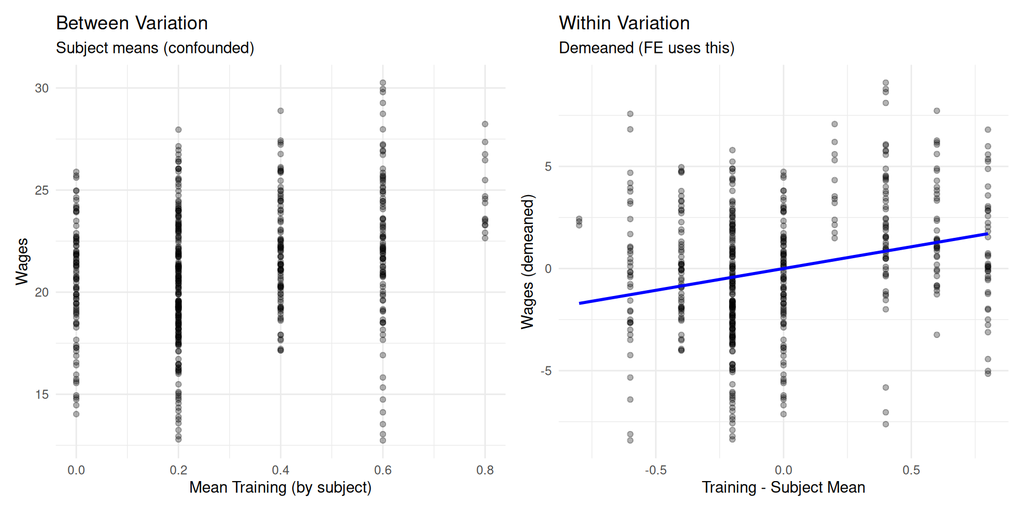

```r
# Show the within vs between variation
p1 <- panel_data |>
  ggplot(aes(x = training_mean, y = wages, group = id)) +
  geom_point(alpha = 0.3) +
  geom_smooth(method = "lm", se = FALSE, color = "red") +
  labs(
    title = "Between Variation",
    subtitle = "Subject means (confounded)",
    x = "Mean Training (by subject)",
    y = "Wages"
  ) +
  theme_minimal()

p2 <- panel_data |>
  mutate(
    training_demeaned = training - training_mean,
    wages_demeaned = wages - mean(wages)  # simplified for visualization
  ) |>
  ggplot(aes(x = training_demeaned, y = wages_demeaned)) +
  geom_point(alpha = 0.3) +
  geom_smooth(method = "lm", se = FALSE, color = "blue") +
  labs(
    title = "Within Variation",
    subtitle = "Demeaned (FE uses this)",
    x = "Training - Subject Mean",
    y = "Wages (demeaned)"
  ) +
  theme_minimal()

library(patchwork)
p1 + p2
```

## Key Takeaways

**TipSummary**

1. **Check the framework** when reading papers: biostatistics “RE” $\neq$ econometrics “RE”
2. **Endogeneity matters**: If time-invariant confounders exist, use FE or Mundlak
3. **Hausman test** helps decide: significant = use FE; non-significant = RE is efficient
4. **Mundlak approach** gives both within and between effects, and allows time-invariant predictors
5. **Experimental data** avoids endogeneity by design; mixed models work well

**WarningWhen Reading Papers, Always Check Which Framework the Authors Are Using!**

The same terms mean different things. Look for clues:

- “Within estimator” or “demeaning” = econometrics FE
- “Random intercept model” = biostatistics mixed model
- Hausman test mentioned = econometrics framework
- `lme4` or `nlme` used = biostatistics framework
- `plm` or `fixest` used = econometrics framework